# Wall-E?

Robots are blind. How do they then move around? This dataset contains ultrasonic sensor data for a robot. Can we predict what this robot will do? More importantly, does having more sensors help or hurt? Can we reduce the cost?

# Setup

```python
import pandas as pd
from sklearn.model_selection import train_test_split, StratifiedKFold, cross_val_score
from sklearn.naive_bayes import GaussianNB
from sklearn.ensemble import RandomForestClassifier
from sklearn.metrics import accuracy_score, f1_score, classification_report, confusion_matrix, ConfusionMatrixDisplay
import matplotlib.pyplot as plt
import seaborn as sns
import numpy as np
```

# Data Set

Freire, A., Veloso, M., & Barreto, G. (2009).  
Wall-Following Robot Navigation Data [Dataset]. UCI Machine Learning Repository.  
https://doi.org/10.24432/C57C8W.

This data set is that of a robot traveling along a wall and the sensor readings + the actions it took given those readings.  
Rows represent one moment in time. It has 24 sonar sensors that measure distances around the robot and the last column is the action of robot. This data set has 5456 rows. Feature set is comprised of these 24 sensor measurements and the target value consists of 4 classes: Move-Forward, Slight-Right-Turn, Sharp-Right-Turn, Slight-Left-Turn.

# Getting Data

```python
data_path = "../data/sensor_readings_24.data"
sensorData24 = pd.read_csv(data_path, header=None)

sensorData24.head()
```

|  | 0 | 1 | 2 | 3 | 4 | 5 | 6 | 7 | 8 | 9 | ... | 15 | 16 | 17 | 18 | 19 | 20 | 21 | 22 | 23 | 24 |
| --- | --- | --- | --- | --- | --- | --- | --- | --- | --- | --- | --- | --- | --- | --- | --- | --- | --- | --- | --- | --- | --- |
| 0 | 0.438 | 0.498 | 3.625 | 3.645 | 5.0 | 2.918 | 5.0 | 2.351 | 2.332 | 2.643 | ... | 0.593 | 0.502 | 0.493 | 0.504 | 0.445 | 0.431 | 0.444 | 0.440 | 0.429 | Slight-Right-Turn |
| 1 | 0.438 | 0.498 | 3.625 | 3.648 | 5.0 | 2.918 | 5.0 | 2.637 | 2.332 | 2.649 | ... | 0.592 | 0.502 | 0.493 | 0.504 | 0.449 | 0.431 | 0.444 | 0.443 | 0.429 | Slight-Right-Turn |
| 2 | 0.438 | 0.498 | 3.625 | 3.629 | 5.0 | 2.918 | 5.0 | 2.637 | 2.334 | 2.643 | ... | 0.593 | 0.502 | 0.493 | 0.504 | 0.449 | 0.431 | 0.444 | 0.446 | 0.429 | Slight-Right-Turn |
| 3 | 0.437 | 0.501 | 3.625 | 3.626 | 5.0 | 2.918 | 5.0 | 2.353 | 2.334 | 2.642 | ... | 0.593 | 0.502 | 0.493 | 0.504 | 0.449 | 0.431 | 0.444 | 0.444 | 0.429 | Slight-Right-Turn |
| 4 | 0.438 | 0.498 | 3.626 | 3.629 | 5.0 | 2.918 | 5.0 | 2.640 | 2.334 | 2.639 | ... | 0.592 | 0.502 | 0.493 | 0.504 | 0.449 | 0.431 | 0.444 | 0.441 | 0.429 | Slight-Right-Turn |

5 rows × 25 columns

# Is Wall-E alone?

Here I check for duplicated rows. I check to make sure there is no duplication that will bias the dataset towards one outcome. The check shows that there is no duplicate rows.

```python
sensorData24.duplicated().sum()
```

```
np.int64(0)
```

# No one is home

The next thing to check is null values. This is crucial because too many null values can hurt the model. Luckily there were no null values in the data set. The data set can be used as is.

```python
sensorData24.isnull().sum()
```

```
0     0
1     0
2     0
3     0
4     0
5     0
6     0
7     0
8     0
9     0
10    0
11    0
12    0
13    0
14    0
15    0
16    0
17    0
18    0
19    0
20    0
21    0
22    0
23    0
24    0
dtype: int64
```

## Visualizing Feature Independence

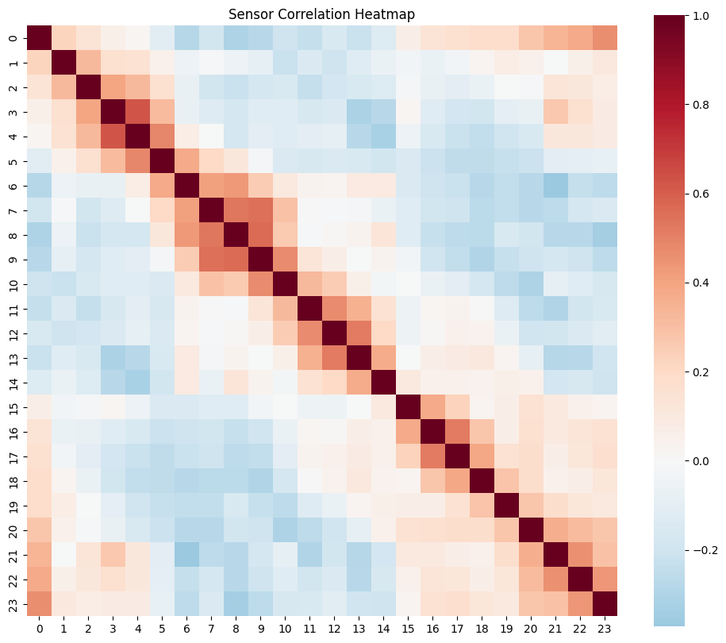

```python
X = sensorData24.iloc[:, :-1]   # all columns except last, feature set
y = sensorData24.iloc[:, -1]    # last column (labels), target

# Compute correlation matrix on numeric features only
corr_matrix = X.corr()

# Plot heatmap
import matplotlib.pyplot as plt
import seaborn as sns

plt.figure(figsize=(12, 10))
sns.heatmap(
    corr_matrix,
    cmap="RdBu_r",
    center=0,
    square=True
)
plt.title("Sensor Correlation Heatmap")
plt.show()
```

## New Approach

Thanks to the heatmap I use a Random Forest model

```python
X_train, X_test, y_train, y_test = train_test_split(
    X, y, test_size=0.2, random_state=42, stratify=y, shuffle=True
)

rf = RandomForestClassifier(
    n_estimators = 200,
    max_depth = None,
    random_state = 42,
    n_jobs = -1
)

rf.fit(X_train, y_train)

y_pred = rf.predict(X_test)

print("Accuracy:", accuracy_score(y_test, y_pred))
print("\nClassification Report:\n", classification_report(y_test, y_pred))
```

```
Accuracy: 0.9935897435897436

Classification Report:
                    precision    recall  f1-score   support

     Move-Forward       0.99      0.99      0.99       441
 Sharp-Right-Turn       1.00      1.00      1.00       420
 Slight-Left-Turn       1.00      0.97      0.98        66
Slight-Right-Turn       0.98      0.99      0.98       165

         accuracy                           0.99      1092
        macro avg       0.99      0.99      0.99      1092
     weighted avg       0.99      0.99      0.99      1092
```

# Wow!

The accuracy is pretty good! This makes me *confused* though, so let’s dig deeper with a confusion matrix.  
While accuracy gives us a single number, the confusion matrix shows exactly which classes are being predicted correctly and where mistakes occur.

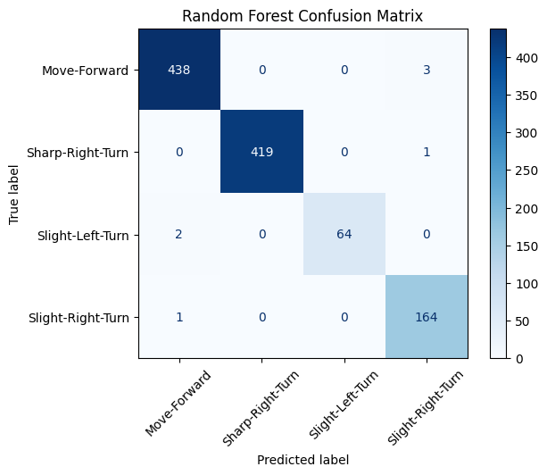

```python
cm = confusion_matrix(y_test, y_pred, labels=rf.classes_)
disp = ConfusionMatrixDisplay(confusion_matrix=cm, display_labels=rf.classes_)
disp.plot(cmap="Blues", xticks_rotation=45)
plt.title("Random Forest Confusion Matrix")
plt.show()
```

# Stress testing with cross validation

To ensure the Random Forest model was not just performing well on a lucky split, I applied **k-fold cross-validation** (k=5). This method trains and tests the model across multiple partitions of the dataset, providing a more reliable measure of generalization.

The results were consistent, with accuracies around 99% across all folds and a very low standard deviation (~0.002). This indicates that the model is not overfitting to a single split but is robust across the dataset.

While the performance appears almost "too good," this is likely due to the curated nature of the dataset (UCI robotics), where the class boundaries are clear and sensor readings are well-structured. In practice, noisier real-world data may yield lower performance, but the cross-validation confirms the model is behaving as expected here.

```python
# 5-fold cross-validation (stratified so class ratios stay balanced)
cv = StratifiedKFold(n_splits=5, shuffle=True, random_state=42)
scores = cross_val_score(rf, X, y, cv=cv, scoring='accuracy')

print("Cross-validation scores:", scores)
print("Mean accuracy:", np.mean(scores))
print("Std deviation:", np.std(scores))
```

```
Cross-validation scores: [0.996337   0.99358387 0.99633364 0.9908341  0.99450046]
Mean accuracy: 0.9943178117330271
Std deviation: 0.0020420071436999523
```

# Comparison

```python
nb = GaussianNB()
nb.fit(X_train, y_train)

# Use the same 5-fold stratified CV for fairness
cv = StratifiedKFold(n_splits=5, shuffle=True, random_state=42)
nb_scores = cross_val_score(nb, X, y, cv=cv, scoring='accuracy')

y_pred_nb = nb.predict(X_test)

print("Naive Bayes CV scores:", nb_scores)
print("Mean accuracy:", np.mean(nb_scores))
print("Std deviation:", np.std(nb_scores))

print("Naive Bayes Accuracy:", accuracy_score(y_test, y_pred_nb))

print("\nNaive Bayes Classification Report:\n")
print(classification_report(y_test, y_pred_nb))
```

```
Naive Bayes CV scores: [0.5467033  0.50504125 0.55362053 0.50504125 0.527956  ]
Mean accuracy: 0.527672465023519
Std deviation: 0.020297286551847028
Naive Bayes Accuracy: 0.49725274725274726

Naive Bayes Classification Report:

                   precision    recall  f1-score   support

     Move-Forward       0.70      0.39      0.50       441
 Sharp-Right-Turn       0.69      0.41      0.51       420
 Slight-Left-Turn       0.44      0.95      0.61        66
Slight-Right-Turn       0.30      0.84      0.44       165

         accuracy                           0.50      1092
        macro avg       0.53      0.65      0.52      1092
     weighted avg       0.62      0.50      0.50      1092
```

# Reduction of Sensors

For this step, I used the UCI dataset with only four sensors. After loading and preprocessing the data, I confirmed that there were no null values. However, I identified 50 duplicate rows out of approximately 5,000, which were removed to prevent potential bias and ensure a cleaner dataset.

```python
data_path = "../data/sensor_readings_4.data"
sensorData4 = pd.read_csv(data_path, header=None)

print(f"Null count: {sensorData4.isnull().sum()}")
print(f"Duplicated: {sensorData4.duplicated().sum()}")
print(f"Row and Column count: {sensorData4.shape}")

sensorData4 = sensorData4.drop_duplicates()
sensorData4.head()
```

```
Null count: 0    0
1    0
2    0
3    0
4    0
dtype: int64
Duplicated: 50
Row and Column count: (5456, 5)
```

|  | 0 | 1 | 2 | 3 | 4 |
| --- | --- | --- | --- | --- | --- |
| 0 | 1.687 | 0.445 | 2.332 | 0.429 | Slight-Right-Turn |
| 1 | 1.687 | 0.449 | 2.332 | 0.429 | Slight-Right-Turn |
| 2 | 1.687 | 0.449 | 2.334 | 0.429 | Slight-Right-Turn |
| 5 | 1.686 | 0.446 | 2.334 | 0.430 | Slight-Right-Turn |
| 6 | 1.684 | 0.451 | 2.330 | 0.432 | Slight-Right-Turn |

# Less is more

I modeled the dataset using only the 4 forward-facing sensors provided in the UCI dataset. The model still achieved very high accuracy. This suggested that reducing the number of sensors did not significantly degrade performance.

The consistency of accuracy across models raises the possibility that one or more sensors strongly dominate decision-making in this robot’s behavior. In other words, a single feature—or a subset—may be disproportionately responsible for determining the robot’s actions. This warrants further investigation into feature importance and redundancy in the dataset.

```python
X4 = sensorData4.iloc[:, :-1]  # all columns except last, feature set
y4 = sensorData4.iloc[:, -1]   # last column (labels), target

X4_train, X4_test, y4_train, y4_test = train_test_split(
    X4, y4, test_size=0.2, random_state=42, stratify=y4, shuffle=True
)

rf = RandomForestClassifier(
    n_estimators = 200,
    max_depth = None,
    random_state = 42,
    n_jobs = -1
)

rf.fit(X4_train, y4_train)

y4_pred = rf.predict(X4_test)

print("Accuracy:", accuracy_score(y4_test, y4_pred))
print("\nClassification Report:\n", classification_report(y4_test, y4_pred))
```

```
Accuracy: 0.9981515711645101

Classification Report:
                    precision    recall  f1-score   support

     Move-Forward       1.00      1.00      1.00       441
 Sharp-Right-Turn       1.00      1.00      1.00       417
 Slight-Left-Turn       1.00      0.97      0.98        65
Slight-Right-Turn       1.00      1.00      1.00       159

         accuracy                           1.00      1082
        macro avg       1.00      0.99      1.00      1082
     weighted avg       1.00      1.00      1.00      1082
```

# Visualize Sensors

To understand which inputs drive the classifier, I first examined per-sensor contribution rather than raw reading counts (counts can be misleading as every sensor records once per sample). I used model-based feature importance to identify dominant sensors and then validated those findings with an ablation study.

The results show Sensor 14 (15° forward-facing) dominates. Using Stratified 5-fold CV on subsets of the top-ranked features:

- Top 1 sensor (Sensor 14) → ~70% accuracy
- Top 2–3 sensors → >90% accuracy
- Top 4–8 sensors → ≈98–99% (plateau; additional sensors add little)

Interpretation. The classifier’s performance depends mainly on a narrow forward-facing arc. This suggests the dataset is highly deterministic and redundant: a few sensors largely determine the label, and the model needs little additional context. Rather than learning a rich policy, the model is effectively capturing a simple trigger behavior—consistent with a robot that drifts until a forward sensor reports a close obstacle, then over-corrects.

What this adds to the story.

- Confirms why Naive Bayes underperforms (correlated sensors) and why Random Forest excels (handles correlation and interactions).
- Shows the robot’s control signal is concentrated in the forward sensors, raising questions about generalization to different walls/environments and whether peripheral sensing is underutilized.

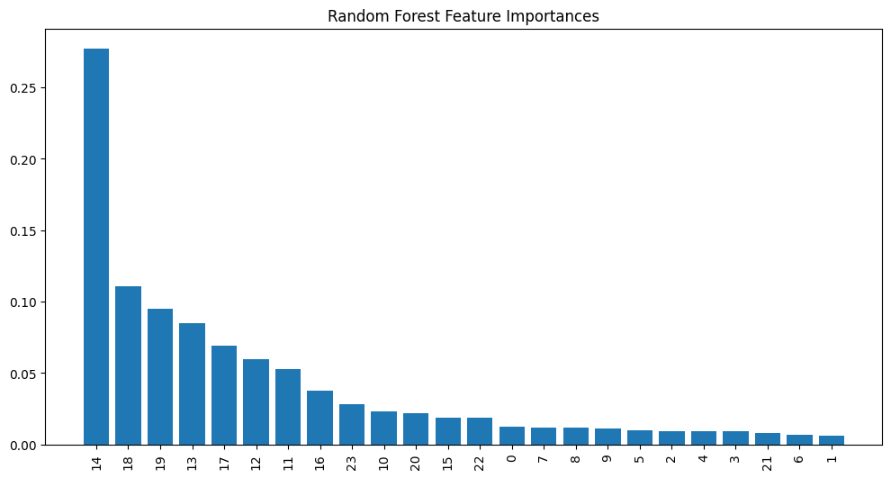

```
Top 1 features -> Mean acc: 0.7256 ± 0.0113
Top 2 features -> Mean acc: 0.9007 ± 0.0105
Top 4 features -> Mean acc: 0.9826 ± 0.0025
Top 8 features -> Mean acc: 0.9960 ± 0.0017
Top 12 features -> Mean acc: 0.9962 ± 0.0019
Top 24 features -> Mean acc: 0.9943 ± 0.0016
```

```python
rf = RandomForestClassifier(n_estimators=300, random_state=42, n_jobs=-1)
rf.fit(X, y)


importances = rf.feature_importances_
indices = np.argsort(importances)[::-1]

plt.figure(figsize=(12,6))
plt.bar(range(X.shape[1]), importances[indices])
plt.xticks(range(X.shape[1]), indices, rotation=90)
plt.title("Random Forest Feature Importances")
plt.show()


cv = StratifiedKFold(n_splits=5, shuffle=True, random_state=42)
for k in [1, 2, 4, 8, 12, 24]:  # test different sensor counts
    topk = indices[:k]
    scores = cross_val_score(rf, X.iloc[:, topk], y, cv=cv, n_jobs=-1)
    print(f"Top {k} features -> Mean acc: {scores.mean():.4f} ± {scores.std():.4f}")
```

# Movement Patterns

By visualizing the counts of the movement, I can see that the majority of the movements are forward then sharp right turns. This supports the finding that the forward sensor arrays are the only sensors at play here. The robot moves forward until it starts veering into the wall, where the forward sensor array senses it and causes the robot to turn right sharply.

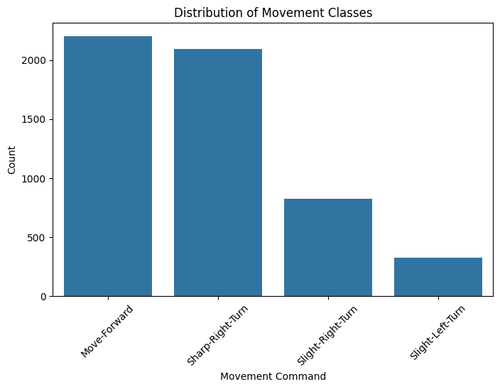

```python
labels = sensorData24[24]

plt.figure(figsize=(8,5))
sns.countplot(x=labels, order=labels.value_counts().index)
plt.title("Distribution of Movement Classes")
plt.xlabel("Movement Command")
plt.ylabel("Count")
plt.xticks(rotation=45)
plt.show()
```

# Sensor 14 Readings only

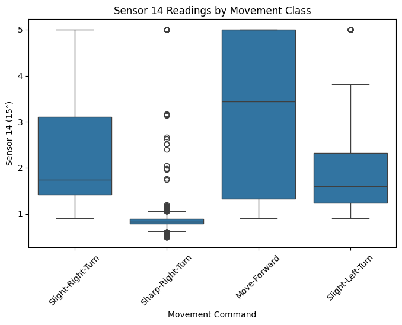

```python
plt.figure(figsize=(8,5))
sns.boxplot(x=sensorData24[24], y=sensorData24[14])
plt.title("Sensor 14 Readings by Movement Class")
plt.xlabel("Movement Command")
plt.ylabel("Sensor 14 (15°)")
plt.xticks(rotation=45)
plt.show()
```

# Impact

The findings have a larger implication: a robot trained on deterministic data like this will perform well in the lab but fail in new environments. That risk is the same in bigger autonomous systems like self-driving cars, where brittle models can mean life-threatening failures. This dataset shows how relying only on forward sensors might be “good enough” for a narrow case but is dangerous for general deployment. It highlights the need for more robust, diverse data collection and careful validation before trusting models in safety-critical systems.

# Story Telling

When I started this project, I expected to use a Gaussian Naive Bayes model, but the data quickly proved otherwise. Random Forest delivered extremely high accuracy, which at first looked like success but really highlighted how deterministic the dataset was. That turned the project into more of an exploration of the dataset itself than just training a classifier. What I learned is that even when accuracy looks great, it doesn’t always mean the model is “smart” — sometimes it’s just memorizing. But we can indeed know what the robot will do and that 24 sensors is overkill and the sweet spot for this particular robot and this particular wall is 4-8 sensors.

# References

Freire, A., Veloso, M., & Barreto, G. (2009).  
Wall-Following Robot Navigation Data [Dataset]. UCI Machine Learning Repository.  
https://doi.org/10.24432/C57C8W.

OpenAI. (2025).ChatGPT[Large language model].OpenAI.  
https://chat.openai.com

# Disclaimer

Portions of the code refinement, data exploration, and narrative structuring were assisted by OpenAI’s ChatGPT (GPT-5). I directed the analysis, made final decisions on preprocessing steps, and selected visualizations, while ChatGPT was used as a learning and drafting tool.